# Milk

Bartosz Lewandowski

09 06 2021

W praktyce zawodowej, coraz częściej możemy się spotkać z terminem szeregów czasowych, który pochodzi z dziedziny statystyki oraz ekonometrii. Głównym założeniem konstruowania szeregów czasowych jest predykcja przyszłych wyników/danych. Z uwagi na rosnące zainteresowanie tą metodą, pojawia się coraz więcej propozycji oraz bilbiotek realizujacych to zagadnienie. Natmoiast nalezy mieć na względzie, że wykorzystanie takowych gotowych metod nie jest równoznaczne z przeprowadzeniem klarownych przewidywań. Co za tym idzie, należy zrozumieć badane dane wraz z ich odpowiednią wcześniejszą dekompozycją. W tym projekcie wpierw przeprowadzimy takową dekompozycję, następnie skorzystamy ze znanych już bibliotek, a nastepnie przejdziemy do zyskujących na popularności, bardziej zautomatyzowanych metod predykcji. Należy również mieć na względzie, że autorzy bilbiotek stosują własne wybrane metody przekształcania danych, chociażby jak wymogi ich wskazywania algorytmom w różnej postaci. Dodatkowo, należy również zdawać sobie sprawę, że im bardziej zautomatyzowana metoda, tym bardziej zaawansowane są jej wewnętrzne metody, nierzadko współtworzone przez doświadczonych programistów.

# Część I - ręczna dekompozycja szeregu

**Kliknij, aby rozwinąć**

## Zaimportowanie zbioru danych+ wstepna analiza

```r
data(milk) # Zaimportowanie danych  z biblioteki "TSA"
str(milk) # Gotowe
```

```
##  Time-Series [1:144, 1] from 1994 to 2006: 1343 1236 1401 1396 1457 1388 1389 1369 1318 1354 ...
##  - attr(*, "dimnames")=List of 2
##   ..$ : NULL
##   ..$ : chr "milk"
```

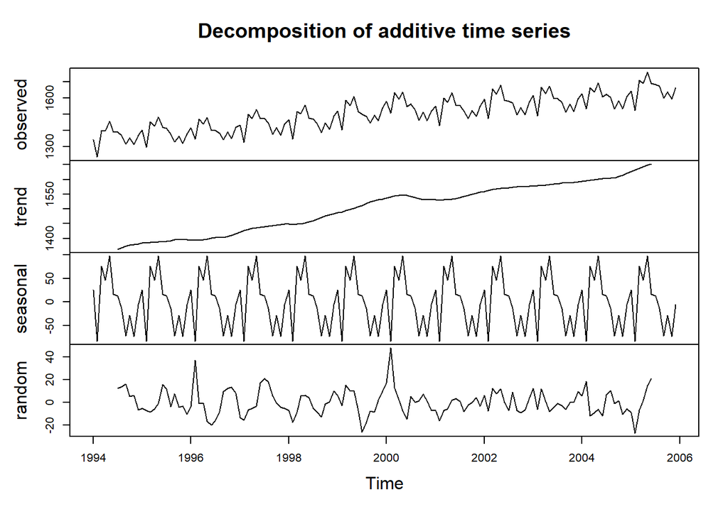

```r
plot(decompose(milk)) # Wstepny podglad z uzyciem funkcji decompose()
```

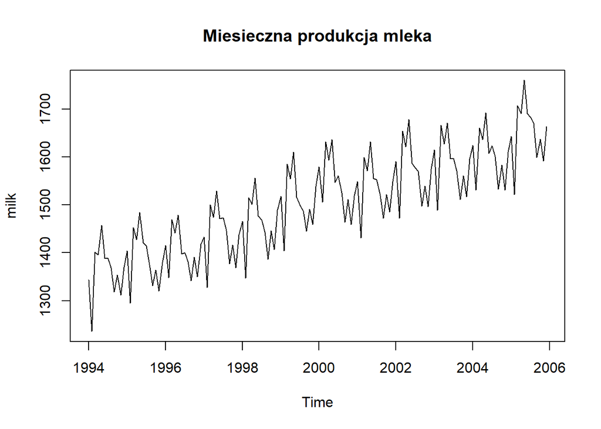

```r
plot(milk, main= "Miesieczna produkcja mleka") # Po ksztalcie wykresu, mozemy wstepnie stwierdzic, ze mamy do czynienia z modelem addytywnym
```

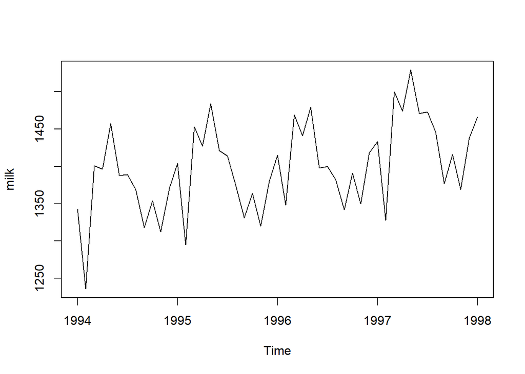

```r
plot(milk %>% window(start= 1994, end= 1998)) # Wstepne podejrzenie pada na freq= 12 (rok)
```

## Szukanie kandydata na trend

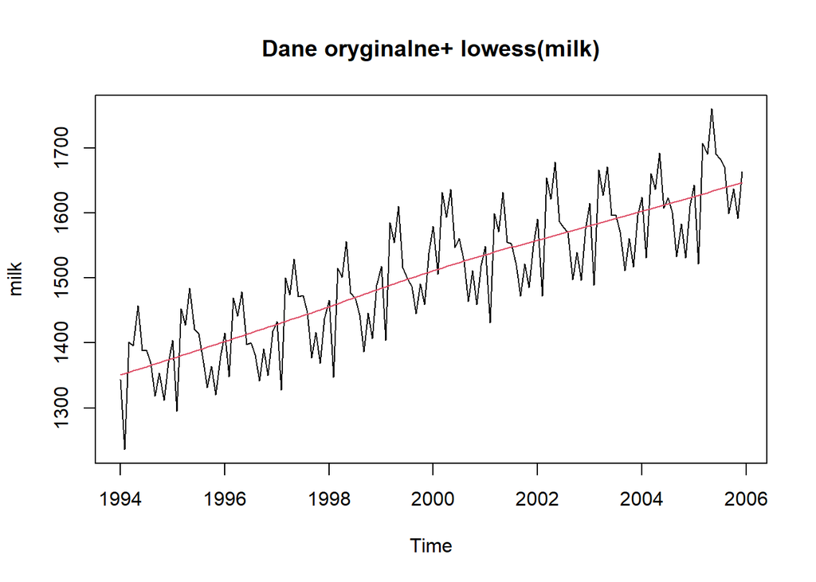

```r
# Do wylonienia kandydatow na trend posluzymy sie kodem z zajec

# Wprowadzmy zmienne
ly <- lowess(milk)
t <- time(milk)
N <- milk %>% length()

# Wykresy porownawczy
plot(milk, main= "Dane oryginalne+ lowess(milk)")
lines(ly, col= 2)
```

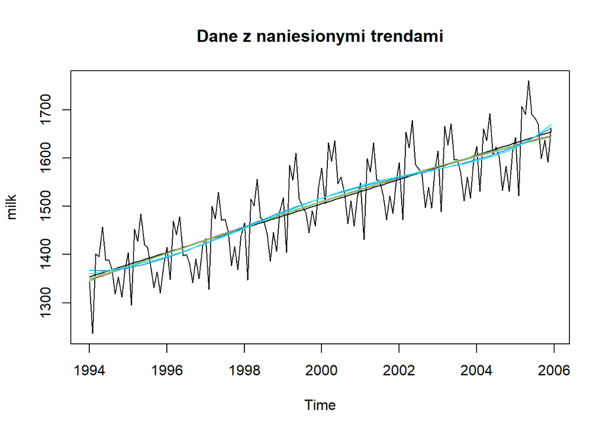

```r
# Teraz naniesmy na wykres kolejne trendy
plot(milk, main= "Dane z naniesionymi trendami")
lines(ly, col= "grey") # Na razie wyszarzamy lowess()

X <- matrix(t)
lsf1<- lsfit(X,milk)
lc<- lsf1$coefficients
yr1 <- lc[1]+ lc[2]*t
lines(yr1,col=1)
err1 <- sum(lsf1$residuals^2)/N

t2 <- (t-mean(time(milk)))^2
X <- cbind(X,t2)
lsf2<- lsfit(X,milk)
lc<- lsf2$coefficients
yr2 <- lc[1]+ lc[2]*t + lc[3]*t2

lines(yr2,col=2)
err2 <- sum(lsf2$residuals^2)/N

t3 <- (t-mean(time(milk)))^3
X <- cbind(X,t3)
lsf3<- lsfit(X,milk)
lc<- lsf3$coefficients
yr3 <- lc[1]+ lc[2]*t + lc[3]*t2 +lc[4]*t3

lines(yr3,col=3)
err3 <- sum(lsf3$residuals^2)/N

t4 <- (t-mean(time(milk)))^4
X <- cbind(X,t4)
lsf4<- lsfit(X,milk)
lc<- lsf4$coefficients
yr4 <- lc[1]+ lc[2]*t + lc[3]*t2 +lc[4]*t3+lc[5]*t4

lines(yr4,col=4)
err4 <- sum(lsf4$residuals^2)/N

t5 <- (t-mean(time(milk)))^5
X <- cbind(X,t5)
lsf5<- lsfit(X,milk)
lc<- lsf5$coefficients
yr5 <- lc[1]+ lc[2]*t + lc[3]*t2 +lc[4]*t3+lc[5]*t4+lc[6]*t5

lines(yr5,col=5)
err5 <- sum(lsf5$residuals^2)/N

t6 <- (t-mean(time(milk)))^6
X <- cbind(X,t6)
lsf6<- lsfit(X,milk)
lc<- lsf6$coefficients
yr6 <- lc[1]+ lc[2]*t + lc[3]*t2 +lc[4]*t3+lc[5]*t4+lc[6]*t5+lc[7]*t6

lines(yr5,col=5)
```

```r
err6 <- sum(lsf6$residuals^2)/N

sprintf("err1:    %7.2f", err1^.5)
```

```
## [1] "err1:      57.92"
```

```r
sprintf("err2:    %7.2f", err2^.5)
```

```
## [1] "err2:      57.80"
```

```r
sprintf("err3:    %7.2f", err3^.5)
```

```
## [1] "err3:      57.79"
```

```r
sprintf("err4:    %7.2f", err4^.5)
```

```
## [1] "err4:      57.40"
```

```r
sprintf("err5:    %7.2f", err5^.5)
```

```
## [1] "err5:      57.35"
```

```r
sprintf("err6:    %7.2f", err6^.5)
```

```
## [1] "err6:      57.01"
```

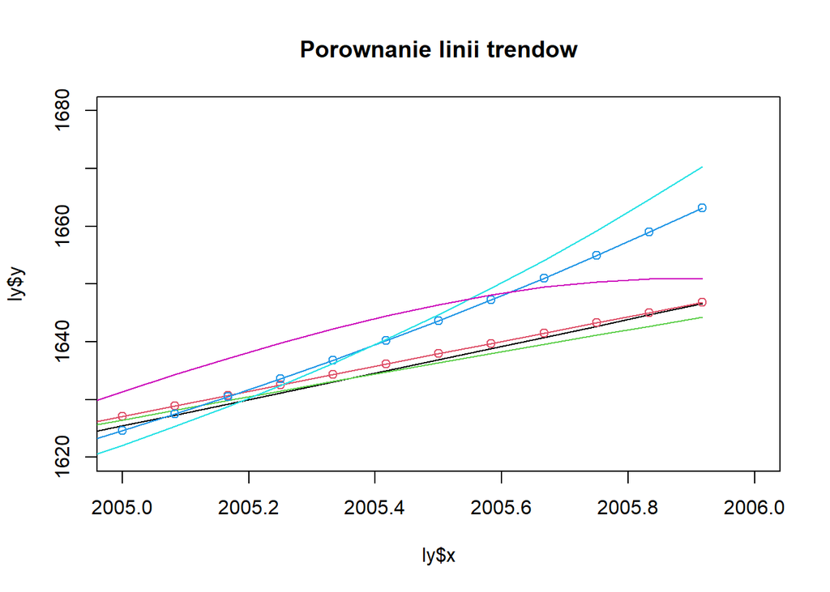

```r
# Najmniejszy blad wykazuje wielomian st. 6

# Porownajmy graficznie zachowanie wzgledem innych trendow
plot(ly, main= "Porownanie linii trendow", ylim= c(1620, 1680), xlim= c(2005, 2006), type= "l")
lines(yr2, col= 2, type= "o") # Wstepny kandydat
lines(yr3, col= 3, type= "l")
lines(yr4, col= 4, type= "o")
lines(yr5, col= 5, type= "l")
lines(yr6, col= 6, type= "l")
```

```r
# Najlepszym kandydatem (najbardziej zblizonym do lowess()) jest yr2 (kolejnym jest yr3)
# ,ale czy aby na pewno?
# Chociaz nie widac znacznej poprawy przy wielomianie st. 6, to linia trendu zaczyna sie zblizac do trendu lowess(milk)
# Czy jest sens rozwazac wielomiany wyzszych stopni niz 6?
# Sprawdźmy to!
```

## Badanie sezonowosci

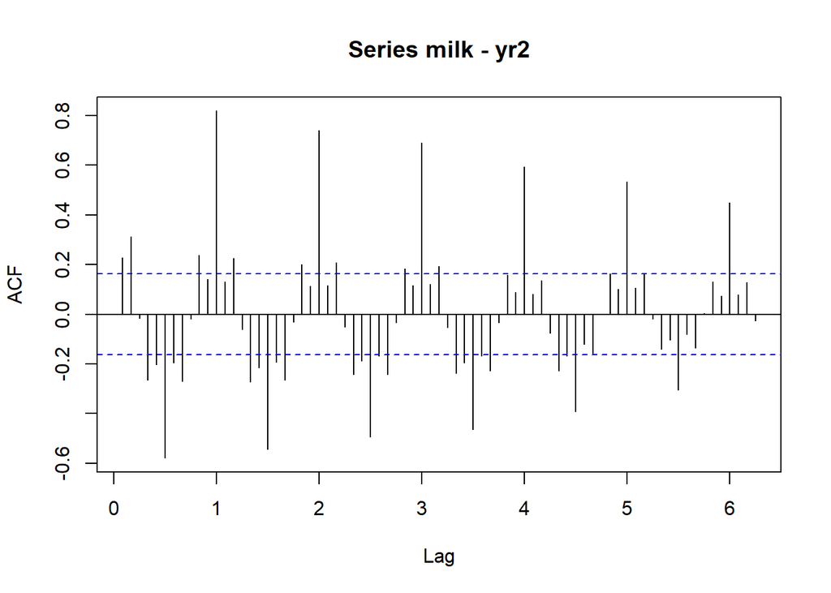

```r
# Zbadajmy sezonowosc dla yr2
milk_acf <- acf(milk- yr2, 75)
```

```r
milk_acf$acf[11:13]
```

[output not shown]

```r
sprintf("Max wartosc:    %7.5f", max(milk_acf$acf[3:length(milk_acf$acf)]))
```

```
## [1] "Max wartosc:    0.81898"
```

```r
sprintf("Pozycja:   %7.0f", which.max(milk_acf$acf[3:length(milk_acf$acf)])+2)
```

```
## [1] "Pozycja:        12"
```

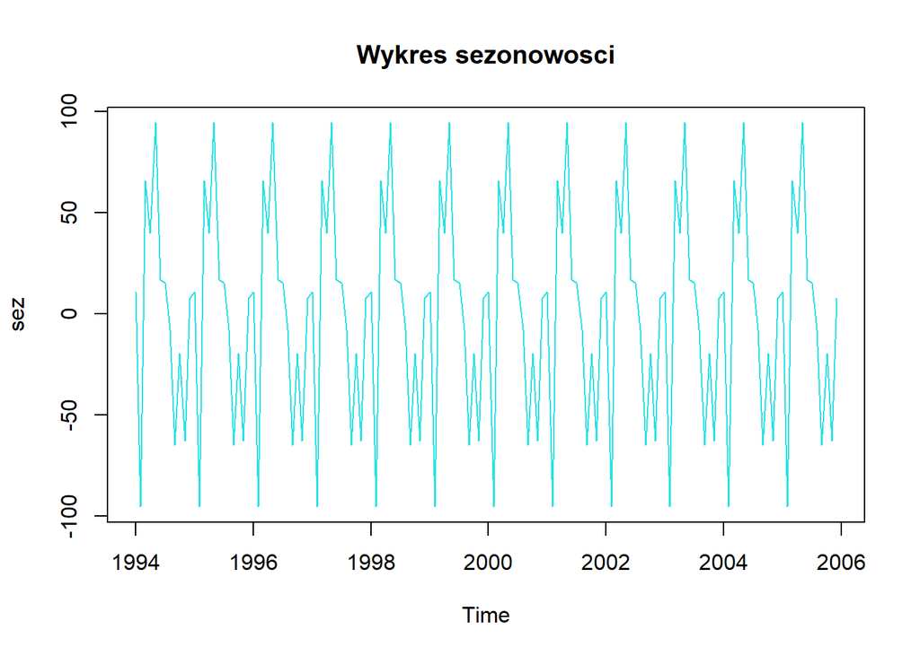

```r
sez <- fSeason(milk, 12)

plot(sez, main= "Wykres sezonowosci", col= 5)
```

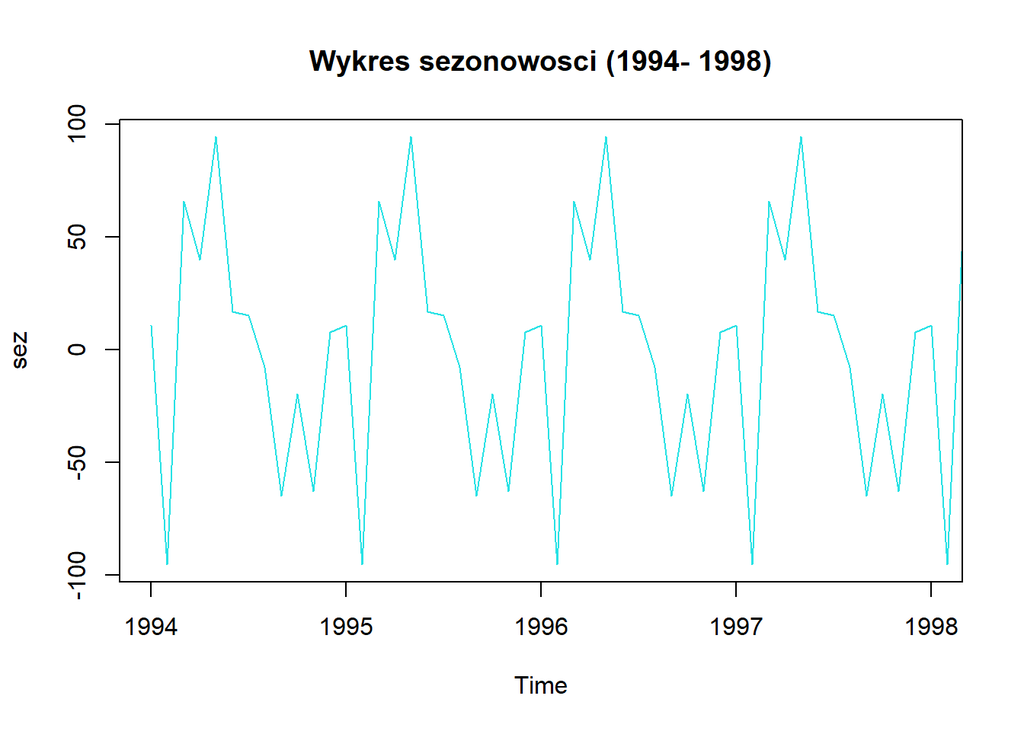

```r
plot(sez, main= "Wykres sezonowosci (1994- 1998)", col= 5, xlim= c(1994,1998))
```

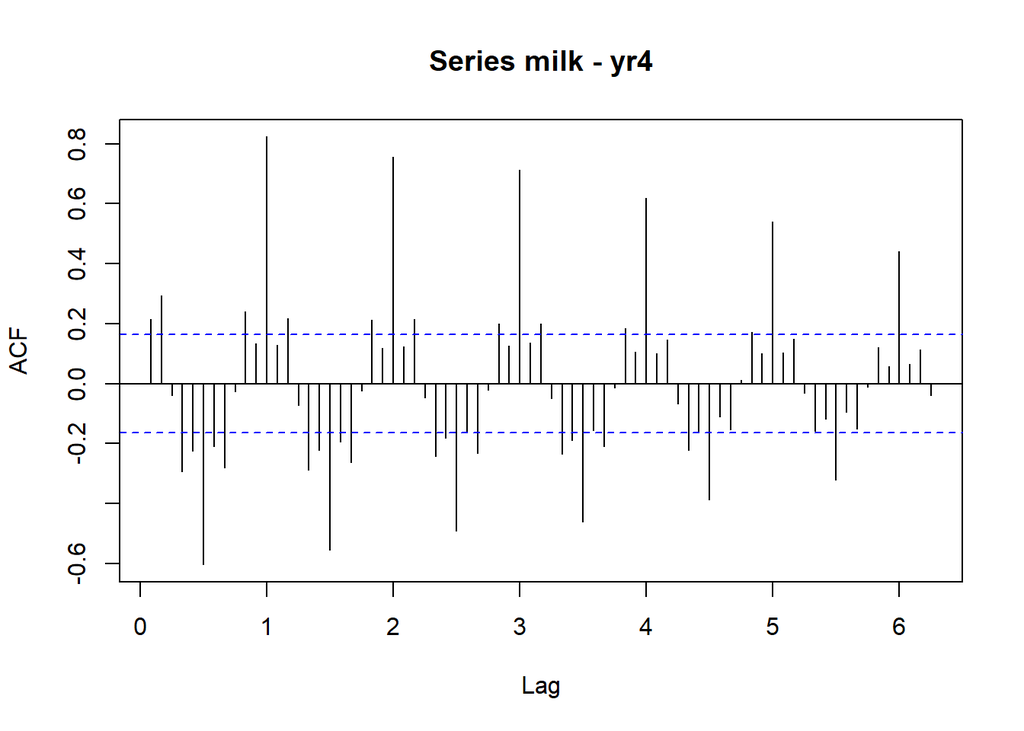

```r
# Pogladowo sprawdzy jeszcze acf() dla yr4 oraz yr6
acf(milk- yr4, 75)
```

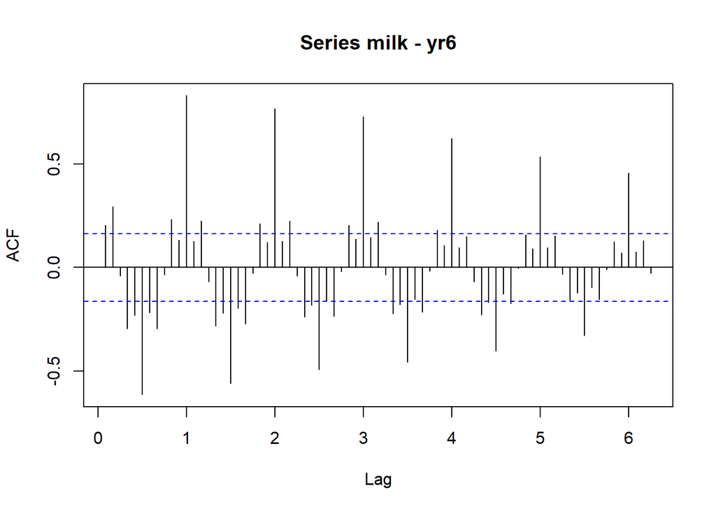

```r
acf(milk- yr6, 75)
```

```r
# Mozna smialo stwierdzic, ze okresowosc sezonowosci w kazdym przypadku bedzie wynosic 12
```

## Sprawdzenie resztek

[figure not shown]

```r
res <- milk- yr2- sez
plot(res, main= "Resztki (yr2)")
```

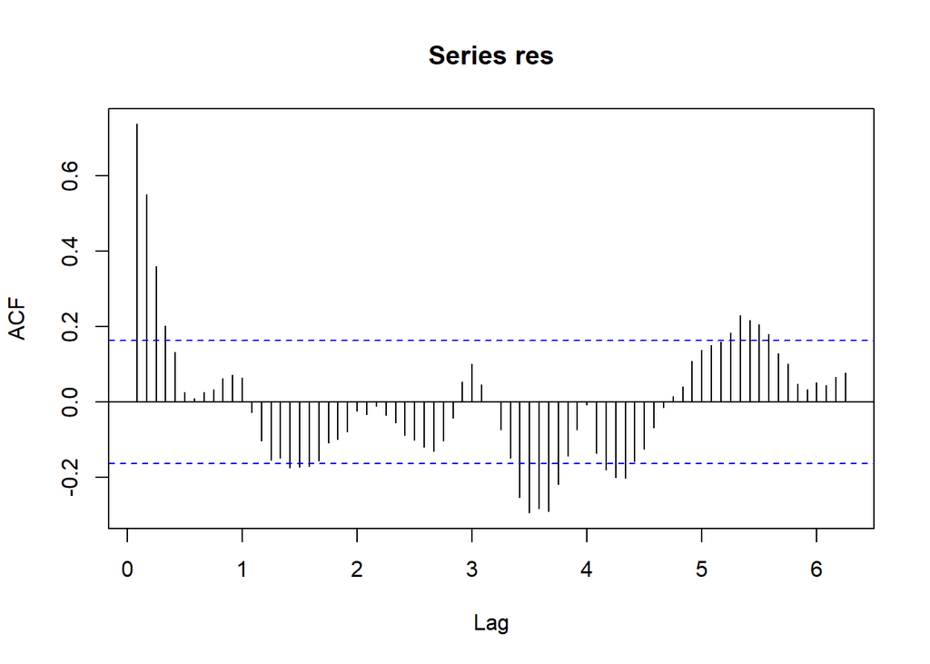

```r
# Autokorelacja resztek
acf(res, 75)
```

```r
# Wynik obiecujacy, ale moze uda nam sie dobrac lepsza linie trendu, ktora zaskutuje lepszym "wyplaszczeniem"?
```

## Lepszy kandydat na trend?

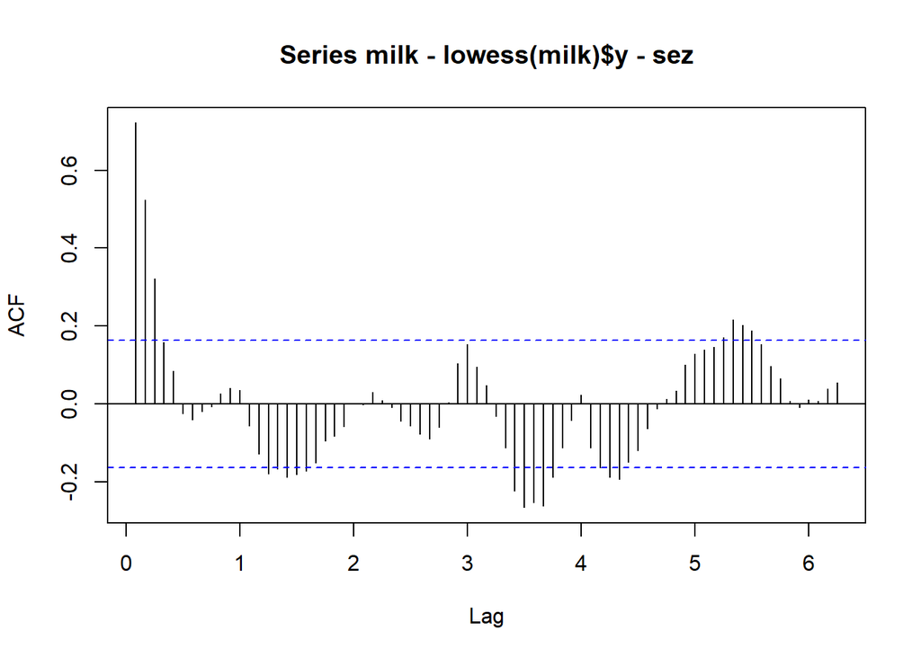

```r
# wykres resztek przy zastosowaniu kolejno st. lowess(milk), 2,3,4,5,6 (przyjmuje ten sam sezon w kazdym przypadku)
tstls <- acf(milk- lowess(milk)$y- sez, 75)
```

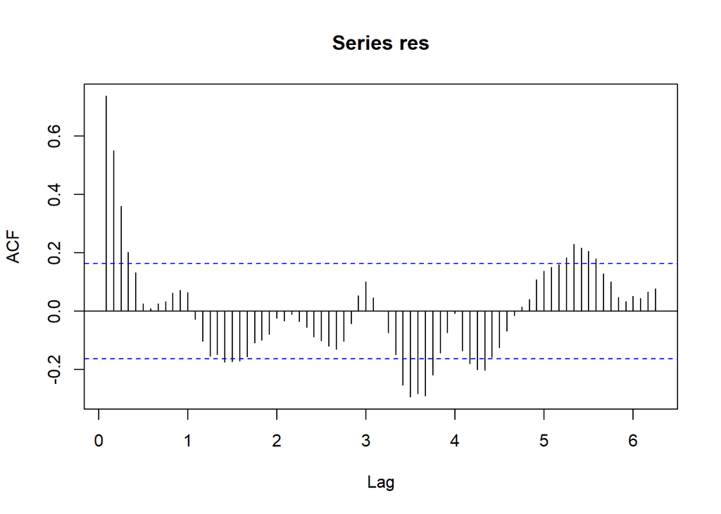

```r
tst2 <- acf(res, 75) # milk- yr2- sez
```

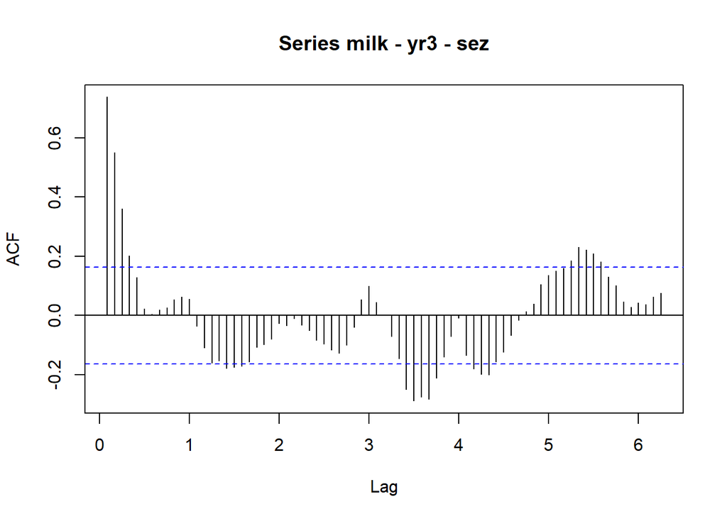

```r
acf(milk- yr3- sez, 75)
```